# Visually Communicating Results from Multilevel Modeling in R

##### Multilevel Modeling – Summer 2019 – Sascha Göbel and Susumu Shikano

**Content**

1. A very brief introduction to ggplot2
2. Graphically displaying results from multilevel models
3. Further reading

## 1. A very brief introduction to ggplot2

We make use of the `ggplot2` package to visually communicate results from multilevel modeling in R. While base R works perfectly fine for this task, `ggplot2` offers a simple workflow where we only supply the data, specify variables to be visualized, and decide how we want to graph them and get a decent looking graph. The output from the `mlAMEs()` function introduced in ‘Postestimation for Multilevel Modeling in R’ is also structured so that it can be directly used with `ggplot2`.

##### Required packages

If you haven’t done so yet, install the `ggplot2` package from CRAN. We also require the `dplyr`, `tidyr`, `lme4`, and `stringr` packages.

```r
install.packages("ggplot2")
```

Attach all packages:

```r
library(ggplot2)
library(dplyr)
library(tidyr)
library(lme4)
library(stringr)
```

##### Building a graph

Building a graph with `ggplot2` always starts with calling `ggplot()`. Within `ggplot()` we specifiy the data frame holding the variables we want to plot through the `data` argument, and the variables themselves through the `mapping` argument:

```r
ggplot(data = data_frame, mapping = aes(x = x_axis_var, y = y_axis_var))
```

Having specified the data and variables, we next add a `geom` to decide how we want to graph the data, e.g. using a scatterplot or to compare point estimates via `geom_point` or using a histogram or a density via `geom_histogram()` or `geom_density`. To add this layer we have to finish the previous line with a `+`.

```r
ggplot(data = data_frame, mapping = aes(x = x_axis_var, y = y_axis_var)) +
  geom_point()
```

And that’s already it. Of course, depending on the chosen `geom`, the arguments in `aes()` might vary. Furthermore, if you want to display groups, change colors, use different datasets, display graphs side by side etc. there are plenty more statements to add and arguments to specify. This just shows the gist of it. Below, we apply `ggplot2` to output from fitted multilevel models and postestimation, new `ggplot2` components are introduced on the way.

## 2. Graphically displaying results from multilevel models

Our main goal in graphically displaying the results from multilevel models is to communicate quantities of substantive interest along with their uncertainty in an easily comprehensible way. Considering the examples that we dealt with in previous sessions, this entails, for instance, showing estimated variation in xenophobic tendendices across German states and counties and how certain these state- and county-specific estimates are, quickly exploring which predictors in a model are most predictive of the outcome of interest and how they compare to each other, illustrating how our estimate of turnout probability and the associated uncertainty varies across income, or how this relationship differs across race groups.

Below, we will visualize results from models fitted in previous sessions along these lines. Instead of going over the process of fitting and postestimation for these models again, we simply import the respective output before constructing the graphs. There are many different ways to present statistical results and customize graphs. This script is not meant to cover them all but to give you some ideas to start with and provide basic skills to further explore this on your own.

##### Getting the data

The data is again the same as in “Frequentist Multilevel Modeling in R I and II”.

To access the data in R, first specify your working directory via `setwd()`.

```r
setwd("FILE/PATH/TO/YOUR/DIRECTORY")
```

and then import the files via `readRDS` (assuming the data is in your working directory, adjust file path if necessary):

```r
xenodat <- readRDS(file = "xenodat.rds")
voterdat <- readRDS(file = "voterdat.rds")
```

##### Summarizing estimates from a multilevel model

We start by visually summarizing estimates from a multilevel model and turn to population-averaged predictions below. Recall the nested linear multilevel model `lm_3` from ‘Frequentist Multilevel Modeling in R I’:

$y_i \sim$ N$(\mu + \alpha_{jk} + \beta x_i , \sigma^2_y)$, for $i = 1, ..., n$  
$\alpha_{jk} \sim$ N$(\gamma_k, \sigma^2_\alpha)$ for $j = 1, ..., J$ for $j = 1, ..., J$  
$\gamma_k \sim$ N$(0, \sigma^2_\gamma)$ for $k = 1, ..., K$

where $y_i$ is a persons’s xenophobic tendency (mean centered, positive values indicate above average and negative values below average xenophobic tendencies), $\mu$ is the population intercept, $\alpha_{jk}$ is a varying-intercept at the county level $J$ nested in states, $\gamma_{k}$ is a varying-intercept at the state level $K$, $\beta$ represents the slope of $x_i$, a person’s sex, $\sigma^2_y$ is the within-county/residual variance, $\sigma^2_\alpha$ denotes the between-county variance, and $\sigma^2_\gamma$ is the between-state variance.

We import the fitted model and the simulated sampling distribution of the parameters to quantify uncertainty.

```r
# import fitted model
lm_3 <- readRDS("lm_3")
# import simulated sampling distribution of estimated parameters
sim_lm_3 <- readRDS("sim_lm_3")
```

Now suppose we want to depict how the states in the data deviate from the estimated average xenophobic tendency. This corresponds to the estimated varying intercepts $\gamma_{k}$ which are deviations from the population intercept $\mu$, which is close to 0 since the outcome is mean centered and relates to the baseline of the individual-level predictor, i.e., females. For males, we had to add the estimated $\beta$. First, we extract the relevant simulated sampling distributions from `sim_lm_3`.

```r
# extract simulated sampling distributions
state_estimates <- data.frame(sim_lm_3@ranef$state[,,1])

# rename columns of county_intercepts to match original names in the data
colnames(state_estimates) <- dimnames(sim_lm_3@ranef$state)[[2]]
```

Next we bring the data into a long format to easily compute quantiles that we want to communicate.

```r
# one column for the states, one column for the respective estimates
state_estimates <- gather(data = state_estimates, key = "state", value = "estimate")

# compute point estimates and 95% confidence intervals
state_estimates <- state_estimates %>%
  group_by(state) %>%
  summarize(fit = mean(estimate),
            lower = quantile(estimate, probs = 0.025),
            upper = quantile(estimate, probs = 0.975))
```

One last step before building the plot is to order the states in `state_estimates` in such a way, that they are displayed in ascending order of the estimates. We then apply this ordering to the data as well, because we also want to plot the underlying data points.

```r
# state variable as factor and ordered according to fit variable
state_estimates$state <- reorder(state_estimates$state, state_estimates$fit)

# apply ordering to data
xenodat$state <- factor(xenodat$state, levels = levels(state_estimates$state))
```

Finally, we build the graph. On the x-axis we map the states, on the y-axis we map the outcome. We use `geom_hline()` to denote $\mu$ via a horizontal line, `geom_pointrange` to speciy the point estimate and confidence intervals, and `geom_point()` to specify the underlying data points. We also add `theme_bw()` for a blank background, `theme()` to depict the x-axis labels with a 45 degree angle, and `labs()` to specify the axis labels. Note how we pass the data and aes at the respective geoms and leave `ggplot()` empty because we supply different datasets.

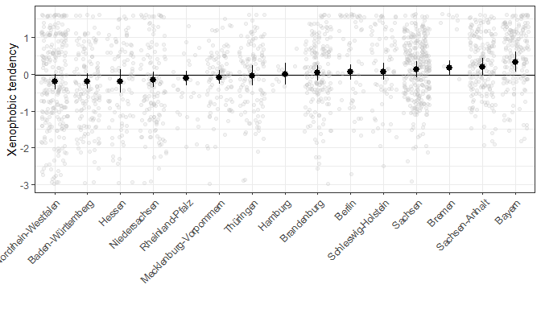

```r
ggplot() +
  geom_hline(yintercept = fixef(lm_3)[1]) +
  geom_point(data = xenodat, aes(x = state, y = xenopho), color = "grey",
             position = position_jitter(), alpha = 0.2) +
  geom_pointrange(data = state_estimates, aes(x = state, y = fit, ymin = lower, ymax = upper)) +
  theme_bw() +
  theme(axis.text.x = element_text(angle = 45, hjust = 1)) +
  labs(y = "Xenophobic tendency", x = "")
```

The underlying data points spread out quite far. Suppose we want to zoom into the plot. Cutting the limits would remove data. Instead, specify `coord_cartesian()`.

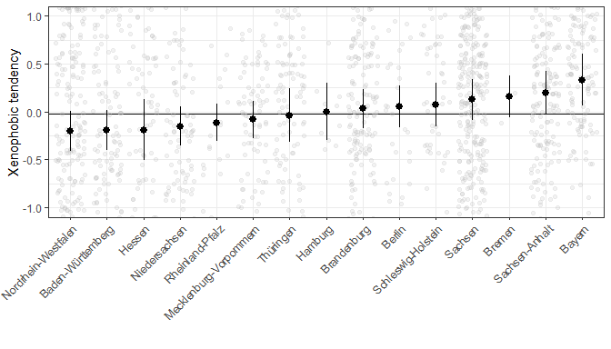

```r
ggplot() +
  geom_hline(yintercept = fixef(lm_3)[1]) +
  geom_point(data = xenodat, aes(x = state, y = xenopho), color = "grey",
             position = position_jitter(), alpha = 0.2) +
  geom_pointrange(data = state_estimates, aes(x = state, y = fit, ymin = lower, ymax = upper)) +
  theme_bw() +
  theme(axis.text.x = element_text(angle = 45, hjust = 1)) +
  labs(y = "Xenophobic tendency", x = "") +
  coord_cartesian(ylim = c(-1,1))
```

We learned from the variance components of the fitted model that most of the variance in the data is actually captured at the county-level, not the state level. Next we visually compare $\alpha_{jk}$ across some counties and display the uncertainty via the full sampling distribution of the estimated parameters. Again, we first extract the simulated sampling distribution and bring the data into a long format. Lets say we are interested in comparing some cities at the extremes from the states Nordrhein-Westfalen and Baden-Württemberg showing below average xenophobic tendencies and from Sachsen and Bremen showing above average xenophobic tendencies.

```r
# extract simulated sampling distributions
county_estimates <- data.frame(sim_lm_3@ranef$county[,,1])

# pick the counties of interest and adjust the column names
county_estimates <- county_estimates[,c(1, 6, 78, 85, 115, 121,40,41)]
colnames(county_estimates) <- c("Freiburg", "Karlsruhe", "Bielefeld", "Krefeld", "Chemnitz", "Dresden", "Bremen", "Bremerhaven")

# one column for the counties, one column for the respective estimates
county_estimates <- gather(data = county_estimates, key = "county", value = "estimate")

# add a state column
county_estimates$state <- ifelse(county_estimates$county == "Freiburg" |
                           county_estimates$county == "Karlsruhe", "Baden-Württemberg",
                    ifelse(county_estimates$county == "Bielefeld" |
                           county_estimates$county == "Krefeld", "Nordrhein-Westfalen",
                    ifelse(county_estimates$county == "Chemnitz" |
                           county_estimates$county == "Dresden", "Sachsen", "Bremen")))
```

Now we build the graph and use `geom_density()` to display the full sampling distribution for the selected counties. The `group` argument is used to automatically depict different distributions for the counties. The `fill` argument is specified to color the area under the curves by states. Lastly, `scale_fill_manual()` sets specific fill colors for the densities belonging to specifc states.

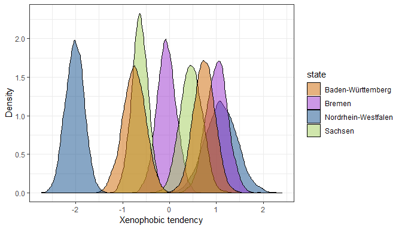

```r
ggplot(data = county_estimates, aes(estimate, group = county, fill = state)) +
  geom_density(alpha = 0.5) +
  scale_fill_manual(values = c("darkorange3", "darkorchid3", "dodgerblue4", "darkolivegreen 3")) +
  theme_bw() +
  labs(x = "Xenophobic tendency", y = "Density")
```

Visually comparing estimated parameters and their uncertainty might also be of interest. We illustrate with the `glm_4` model from ‘Frequentist Multilevel Modeling in R II’.

$y_i \sim$ Bin$(n_i, \pi_i)$  
$\pi_i =$ logit$^{-1}(\mu + \alpha_{j} + \gamma_{k} + \delta_{l} + \zeta_{m} + \beta x_i)$, for $i = 1, ..., n$  
$\alpha_j \sim$ N$(0, \sigma^2_\alpha)$ for $j = 1, ..., J$  
$\gamma_k \sim$ N$(0, \sigma^2_\gamma)$ for $j = 1, ..., K$  
$\delta_l \sim$ N$(0, \sigma^2_\delta)$ for $j = 1, ..., L$  
$\zeta_m \sim$ N$(\beta_1 u_m, \sigma^2_\zeta)$ for $j = 1, ..., M$

where $y_i$ is turnout in the 2018 general election, $\pi_i$ is the probability to turnout, $\mu$ is the population intercept, $\alpha_{j}$, $\gamma_k, \delta_l,$ and $\zeta_m$ are varying-intercepts at race, age, party, and congressional district groups respectively, $\beta$ represents the slope of $x_i$, a person’s income, $\beta_1$ is the slope of the congressional district-level predictor $u_m$, the incumbent party before the 2018 election, and the $\sigma$’s denote the group-level variances.

For building the graphs we proceed as above but add `coord_flip()` to turn the plot around.

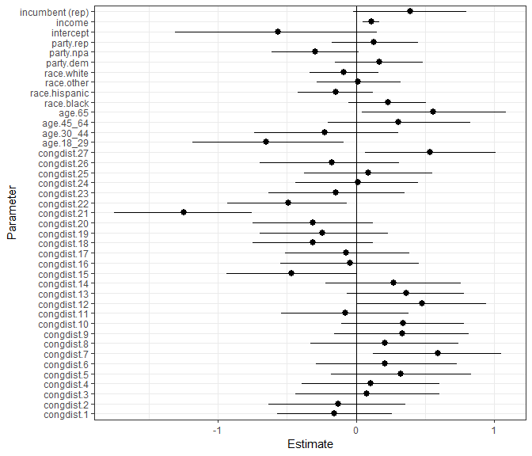

```r
# import fitted model
glm_4 <- readRDS("glm_4")

# import simulated sampling distribution of estimated parameters
sim_glm_4 <- readRDS("sim_glm_4")

# extract simulated sampling distributions
fixed_coefs <- data.frame(sim_glm_4@fixef)
var_intercepts <- data.frame(sim_glm_4@ranef)

# rename columns
colnames(fixed_coefs)[c(1,3)] <- c("intercept", "incumbent (rep)")
colnames(var_intercepts) <- str_replace(colnames(var_intercepts), "\\.\\..+", "")

# bring into long format and stack
fixed_coefs <- gather(data = fixed_coefs, key = "parameter", value = "estimate")
var_intercepts <-  gather(data = var_intercepts, key = "parameter", value = "estimate")
estimates <- rbind(var_intercepts, fixed_coefs)

# specify order of parameters for plotting
estimates$parameter <- factor(estimates$parameter, levels = unique(estimates$parameter))

# compute point estimates and 95% confidence intervals
estimates <- estimates %>%
  group_by(parameter) %>%
  summarize(fit = mean(estimate),
            lower = quantile(estimate, probs = 0.025),
            upper = quantile(estimate, probs = 0.975))

# build the graph
ggplot(data = estimates, aes(x = parameter, y = fit, ymin = lower, ymax = upper)) +
  geom_hline(yintercept = 0) +
  geom_pointrange() +
  theme_bw() +
  labs(x = "Parameter", y = "Estimate") +
  coord_flip()
```

Of course, since this is a generalized linear model, the estimates do not make intuitive sense. So this graph is only suitable to compare the estimated parameters and their uncertainty to each other.

##### Communicating population-averaged predictions

While the parameters of a multilevel model can be of substantive interest, we usually apply some kind of postestimation to make inferences about the outcome of interest across specific covariate values. We begin illustrating this with the model `lm_4` from ‘Frequentist multilevel modeling in R I’. This is an extension of `lm_3` in that the quota of foreigners and the squared quota of foreigners are added as group-level predictors at the county level.

In ‘Postestimation for Multilevel Modeling in R’ we have generated population-averaged predictions based on this model to make inferences about the change in average xenophic tendencies across different levels of the quota of foreigners in counties. The custom `mlAMES()` function used to generate these predictions yields an output that can be directly fed into `ggplot()`. We import the population-averaged predictions and generate two different graphs, a so-called spaghetti plot using `geom_line()` and a rather classical graph with a fit curve and confidence bounds using `geom_line()` and ``geom_ribbon()`. For the spaghetti plot we use the `group` argument to show a line for each of the 4000 parameter draws. `geom_rug()` is additionally supplied in both plots to show the underlying data and `scale_x_continuous()` to remove the gap from the start and end of the x-axis.

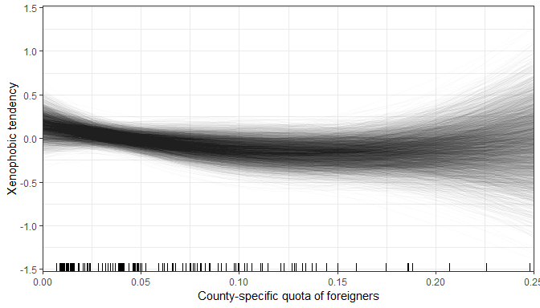

```r
# import population-averaged predictions
postest_lm_4 <- readRDS("postest_lm_4")

# build spaghetti plot
ggplot() +
  geom_line(data = postest_lm_4, aes(x = x, y = y, group = draw), alpha = I(1/sqrt(4000))) +
  geom_rug(data = xenodat, aes(x = foreignq)) +
  theme_bw() +
  labs(y = "Xenophobic tendency", x = "County-specific quota of foreigners") +
  scale_x_continuous(expand = c(0,0))
```

For the classical display we first summarize the postestimates.

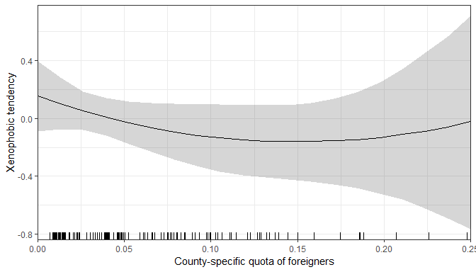

```r
# summarize population-averaged predictions
sum_postest_lm_4 <- postest_lm_4 %>%
  group_by(x) %>%
  summarize(lower = quantile(y, prob = 0.025),
            upper = quantile(y, prob = 0.975),
            fit = quantile(y, prob = 0.5))

# build the graph
ggplot() +
  geom_ribbon(data = sum_postest_lm_4, aes(x = x, ymin = lower, ymax = upper), alpha = 0.2) +
  geom_line(data = sum_postest_lm_4, aes(x = x, y = fit)) +
  geom_rug(data = xenodat, aes(x = foreignq)) +
  theme_bw() +
  labs(y = "Xenophobic tendency", x = "County-specific quota of foreigners") +
  scale_x_continuous(expand = c(0,0))
```

Next, suppose we want to show a graph similar to the one above with the parameters from the model `glm_4` but this time showing probabilities that are intuitively interpretable. We illustrate with postestimates from the Bayesian logit model `fit_ml_glm` which we estimated in ‘Bayesian Multilevel Modeling in R’. This is basically the same model as `glm_4` but without the group-level predictor.

Population-averaged predictions were generated for the race, age, and party variables. Again, we create a graph showing the whole sampling distribution as well as a classical plot.

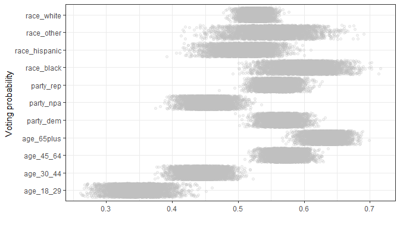

```r
# import population-averaged predictions and stack together
race_black <- readRDS("race-black")
race_hispanic <- readRDS("race-hispanic")
race_other <- readRDS("race-other")
race_white <- readRDS("race-white")
party_dem <- readRDS("party-dem")
party_rep <- readRDS("party-rep")
party_npa <- readRDS("party-npa")
age_18_29 <- readRDS("age-18-29")
age_30_44 <- readRDS("age-30-44")
age_45_64 <- readRDS("age-45-64")
age_65plus <- readRDS("age-65plus")
postest_2 <- rbind(race_black, race_hispanic, race_other, race_white,
                   party_dem, party_rep, party_npa,
                   age_18_29, age_30_44, age_45_64, age_65plus)
postest_2$parameter <- rep(c("race_black", "race_hispanic", "race_other", "race_white",
                             "party_dem", "party_rep", "party_npa",
                             "age_18_29", "age_30_44", "age_45_64", "age_65plus"),
                           each = 4000)

# build graph
ggplot(data = postest_2, aes(y = y, x = parameter)) +
  geom_point(color = "grey",
             position = position_jitter(), alpha = 0.2) +
  theme_bw() +
  labs(x = "Voting probability ", y = "") +
  coord_flip()
```

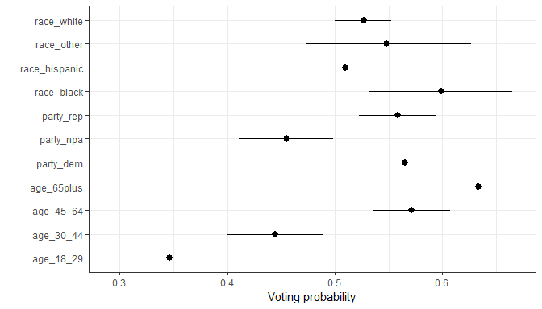

```r
# summarize the postestimates
sum_postest_2 <- postest_2 %>%
  group_by(parameter) %>%
  summarize(lower = quantile(y, prob = 0.025),
            upper = quantile(y, prob = 0.975),
            fit = quantile(y, prob = 0.5))

# build the graph
ggplot(data = sum_postest_2, aes(x = parameter, y = fit, ymin = lower, ymax = upper)) +
  geom_pointrange() +
  theme_bw() +
  labs(x = "", y = "Voting probability") +
  coord_flip()
```

Finally we have a look at `glm_5` estimated in ‘Frequentist Multilevel Modeling II’. Again, this is just an extension of `glm_4`, adding a varying-slope for the income predictor across race.

Our goal is to visuallize how the slope of the predictor income varies across race.

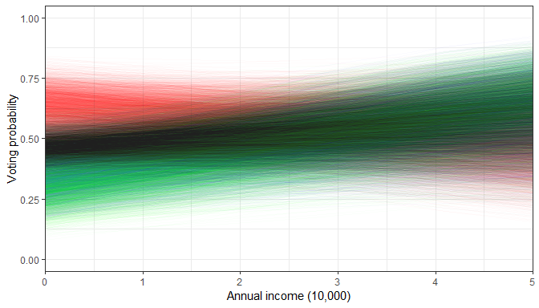

```r
# import population-averaged predictions
race_black_slope <- readRDS("race-black-slope")
race_hispanic_slope <- readRDS("race-hispanic-slope")
race_other_slope <- readRDS("race-other-slope")
race_white_slope <- readRDS("race-white-slope")

# build the graph
ggplot() +
  theme_bw() +
  geom_line(data = race_black_slope, aes(x = x, y = y, group = draw), alpha = I(1/sqrt(4000)), color = "red") +
  geom_line(data = race_hispanic_slope, aes(x = x, y = y, group = draw), alpha = I(1/sqrt(4000)), color = "blue") +
  geom_line(data = race_other_slope, aes(x = x, y = y, group = draw), alpha = I(1/sqrt(4000)), color = "green") +
  geom_line(data = race_white_slope, aes(x = x, y = y, group = draw), alpha = I(1/sqrt(4000))) +
  labs(x = "Annual income (10,000)", y = "Voting probability") +
  coord_cartesian(xlim = c(0,5)) +
  scale_x_continuous(expand = c(0,0))
```

With such an overlap, a classical plot might be more appropriate.

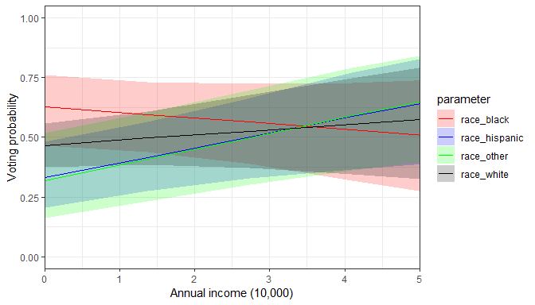

```r
# stack the prediction an summarize
postest_3 <- rbind(race_black_slope, race_hispanic_slope,
                   race_other_slope, race_white_slope)
postest_3$parameter <- rep(c("race_black", "race_hispanic", "race_other", "race_white"),
                           each = 80000)
sum_postest_3 <- postest_3 %>%
  group_by(parameter, x) %>%
  summarize(lower = quantile(y, prob = 0.025),
            upper = quantile(y, prob = 0.975),
            fit = quantile(y, prob = 0.5))

# build the graph
ggplot() +
  geom_ribbon(data = sum_postest_3, aes(x = x, ymin = lower, ymax = upper, fill = parameter), alpha = 0.2) +
  geom_line(data = sum_postest_3, aes(x = x, y = fit, color = parameter)) +
  scale_color_manual(values = c("red", "blue", "green", "black")) +
  scale_fill_manual(values = c("red", "blue", "green", "black")) +
  theme_bw() +
  labs(y = "Voting probability", x = "Annual income (10,000)") +
  coord_cartesian(xlim = c(0,5)) +
  scale_x_continuous(expand = c(0,0))
```

## Further reading

- [Bowman, W. Adrian. 2019. Graphics for Uncertainty. Journal of the Royal Statistical Society A, 182, 2.](https://rss.onlinelibrary.wiley.com/doi/10.1111/rssa.12379)
- [Gabry, Jonah, Daniel Simpson, Aki Vehtari, Michael Betancourt, and Andrew Gelman. 2019. Visualization in Bayesian Workflow. Journal of the Royal Statistical Society A, 182, 2.](https://rss.onlinelibrary.wiley.com/doi/full/10.1111/rssa.12378)
- [Gelman, Andrew and Iain Pardoe. 2007. Average Predictive Comparisons for Models with Nonlinearity, Interactions, and Variance Components. Sociological Methodology, 37, 1.](https://journals.sagepub.com/doi/abs/10.1111/j.1467-9531.2007.00181.x)
- [Ghitza, Yair and Andrew Gelman. 2013. Deep Interactions with MRP. Election Turnout and Voting Patterns Among Small Electoral Subgroups. American Journal of Political Science, 57, 3.](https://onlinelibrary.wiley.com/doi/full/10.1111/ajps.12004)
- Gelman, Andrew and Jennifer Hill. 2007. Data analysis using regression and multilevel/hierarchical models. Cambridge: Cambridge University Press.
- [Ggplot2](https://ggplot2.tidyverse.org/)
- [Kastellec, Jonathan P. and Eduardo L. Leoni. 2007. Using Graphs Instead of Tables in Political Science. Perspectives on Politics, 5, 4](https://www.cambridge.org/core/journals/perspectives-on-politics/article/using-graphs-instead-of-tables-in-political-science/9FD63E9EE686AF046732191EE8A68034)
- [King, Gary, Michael Tomz, and Jason Wittenberg. 2000. Making the Most of Statistical Analyses. Improving Interpretation and Presentation. American Journal of Political Science, 44, 2.](https://www.jstor.org/stable/pdf/2669316.pdf?refreqid=excelsior%3Adc5cc8978c78b96b952d29b6ba6a7a20)